# rowiz (quick) guide

## Introduction

### Purpose of this package

The visualisation part of this package aims towards a **consistent visual standard** for all figures produced by the team.

The goal is that any plot created with this package is:

- Immediately understandable without visual clutter
- Focused on the data, not on decoration
- Readable from a distance (presentations, conferences, large screens)
- Safe to print and embed in reports without quality loss
- Consistent across people, projects, and time

### General Visual Philosophy

First comes the info and then comes the art. The data must be the most visible element in the figure. Everything else (grid, text, legend, colors, margins) exists to support readability.

#### Color Philosophy

Color is never used decoratively — only to encode information.

- **For 3 or more colors**: Viridis palette
  - Perceptually uniform
  - Colorblind-safe
  - Professional and calm tones
  - Good contrast on white background
- **For 2 colors only**: cadetblue & coral
  - In this exceptional case, viridis is not used as its first two colors (purple and yellow) provide poor contrast on white when used alone. This custom pair ensures immediate visual distinction without harsh contrast.

## How to use

### Load

Recommendations for use:

1. Download/Clone to get this package.
2. Place it in your project directory alongside /src, /data and /output. This way every study has the appropriate rowiz attached to it and can be reproduced even if archived. Open your project folder in your prefered R IDE .
3. Install devtools if not installed.
4. Do devtools::load_all(“rowiz/rowiz”) .

You can now use all the methods provided in it. Note that it’s not permanently installed, in a new R session you need to load it again.

### How to apply the theme

Two options:

- In the beginning of your script do `theme_see(theme_professional())`
- Add `+ theme_professional()` to your every plot

### How to export your plots

In order for all plots to be consistent in terms of sizing and quality, a function to export is provided. To use it for saving a simple plot named `plot` that has a legend do:

`save_plot(plot,rows=1,columns=1,legend="y",filename="plot.png")`

You can use the same function to save any kind of plot, if for example you have a large composite plot that consists of 4 subplots arranged in 2x2, just change rows=2 and columns=2.

By using this function, the aspect ratio is ensured to be 1:1.4 (so that the plot is slightly longer than it is high, it tends to be easier to understand) and if a legend exists it is offsetted a little to make breathing space for it. Furthermore, the absolute size of all similar plots is the same and the resolution is forced to 300 dpi so that no pixelization occurs when projected on large screens.

## Available plots

Setup:

```r
devtools::load_all("../rowiz")
```

```
## ℹ Loading rowiz
##
## ─────────────────────────────────────────────────────────
##   You have loaded Rowiz. Type `rowiz_help()` for guidance
## ─────────────────────────────────────────────────────────
```

```r
library(ggplot2)
theme_set(theme_professional())
df <- read_input_dataframe("example_dataframe_itm.csv")
```

### Input variable plots

**Individual plots** are available for almost all useful scenario parameters. They are called ‘plot_’ and the name of the variable not exactly as it appears in the dataframe but at least in an understandable way like for example `plot_waiting_time`. There’s tab completion so try your best to guess :P

Two **global plots** of all input parameters are available with `viz_all_input_parameters`, in case you want to see literally everything.

And we offer tailor made plot combinations that you can get as-is and use for your convenience:

#### Material composition

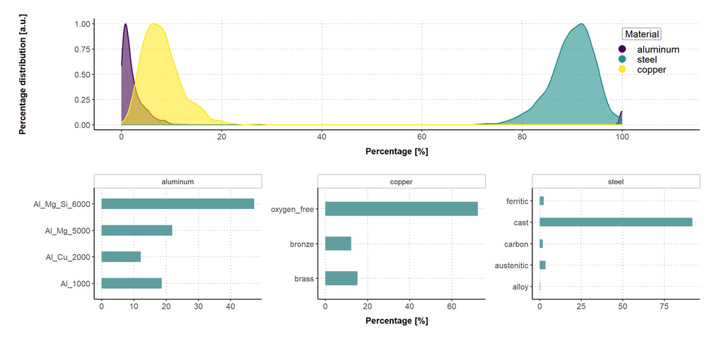

```r
plot_materials(df)
```

#### Irradiation parameters

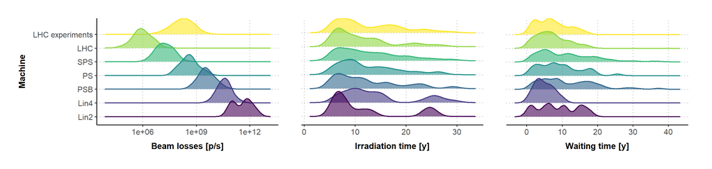

```r
plot_irradiation_parameters(df)
```

#### The above combined

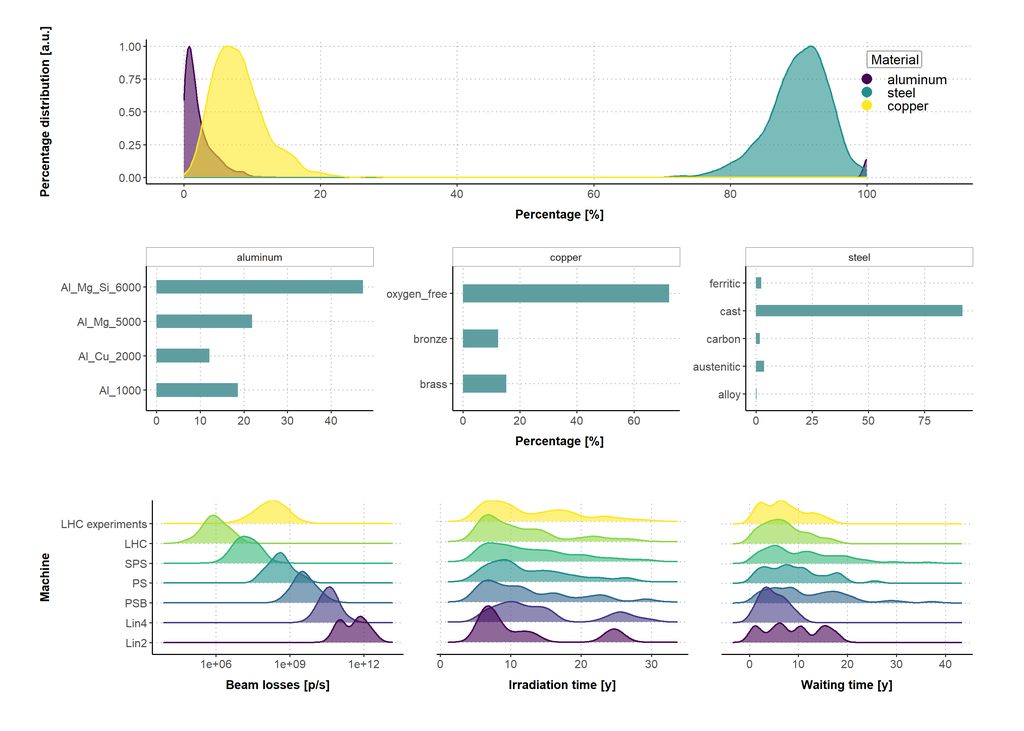

```r
plot_scenario_parameters(df)
```

#### Mass-related physical characteristics

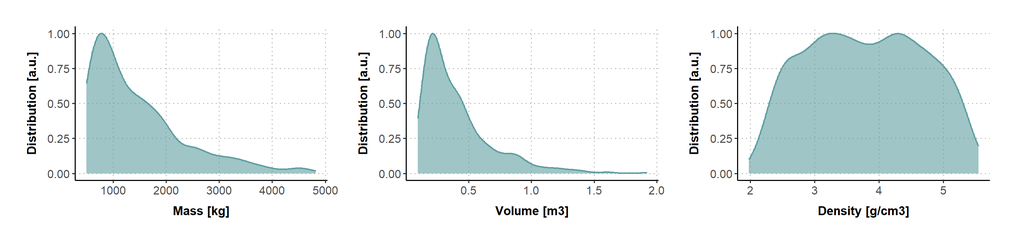

```r
plot_mass_info(df)
```

## Available tools for data preparation

### Reading csv

Because R is weird, if you forget to explicitly specify the appropriate argument, `read.csv` is going to transform the column names into a “fixed” version accepted by R, so Co-60 will become Co.60 etc. And then some functions here will crash (some no because I put a failsafe but I’m old and I forget). To avoid this, there’s a function provided that will force all options to what we need them to be. Use it like:

`df <- read_input_dataframe(filepath)`